# Lab 3: COVID-19

Ecosystem Science and Sustainability 330

Author

Neva Morgan

```r
library(tidyverse)
library(zoo)
library(flextable)
library(ggplot2)
library(dplyr)
library(lubridate)
```

```r
url <- 'https://raw.githubusercontent.com/nytimes/covid-19-data/master/us-counties.csv'
covid <- read.csv(url)
```

### **Question 1:** **Public Data**

#### Take a moment to reflect on the value of open data:

1. How does easy access to historical and real-time environmental, data shape our understanding of climate trends, resource management, and public health? What happens when this data disappears or becomes inaccessible? The role of independent archiving and collaborative stewardship has never been more critical in ensuring scientific progress and accountability.
   1. It’s crucial for data especially concerning climate trends, resource management, and public health to be public information, but I can understand the concern of data privacy as it relates to foreign body intentions. Certain aspects of data are vital to be kept private, for example, even data that is pulled from a CitSci organization must have a check of intentions with the data they are requesting. I think for future projections of any real data that is interacting with people internationally, that should be public knowledge. Giving the ability of access is crucial in developing possible new strategies for combating and mitigating lasting effects of climate change. It can difficult for data scientists to make accurate predictions for let’s say climate models. This informaition is important not just for those tnhat love to study it, but for the future of human development.

~~~

### **Question 2: Daily Summary**

Focused criteria to use to place countries on the watch list for COVID-19:

- More than 100 new cases per 100,000 residents over the past 14 days…

OBJECTIVES:

1. cumulative cases in the 5 worst counties

```r
my.date <- as.Date("2022-02-01")
my.state <- "Colorado"
```

2. total **NEW** cases in the 5 worst counties

```r
covid_data <- covid

colorado <- covid_data |>
  filter(state == my.state) |>
  group_by(county) |>
  arrange(date) |>
  mutate(new_cases = cases - lag(cases),
         new_deaths = deaths - lag(deaths)) |>
  ungroup()
```

```r
filter(colorado, date == my.date) |>
  slice_max(cases, n = 5) |>
  select(Date = date, County = county, Cases = cases) |>
  flextable() |>
  set_caption(caption = "Most Total Cases")
```

| Date | County | Cases |
| --- | --- | --- |
| 2022-02-01 | El Paso | 170,673 |
| 2022-02-01 | Denver | 159,022 |
| 2022-02-01 | Arapahoe | 144,255 |
| 2022-02-01 | Adams | 126,768 |
| 2022-02-01 | Jefferson | 113,240 |

```r
filter(colorado, date == my.date) |>
  slice_max(cases, n = 5) |>
  select(Date = date, County = county, Cases = new_cases) |>
  flextable() |>
  set_caption(caption = "Most NEW Cases")
```

[output not shown]

# **Question 3: Normalizing Data**

#### 1. Given the above URL, and guidelines on string concatenation and formatting, read in the population data and (1) create a five digit FIP variable and only keep columns that contain “NAME” or “2021” (remember the tidyselect option found with ?dplyr::select). Additionally, remove all state level rows (e.g. COUNTY FIP == “000”)

```r
pop_url <- 'https://www2.census.gov/programs-surveys/popest/datasets/2020-2023/counties/totals/co-est2023-alldata.csv'

pop_data <- read.csv(pop_url) |>
  filter(COUNTY != "000") |>
  mutate(fips = sprintf("%05s", paste0(STATE, COUNTY))) |>
  select(fips, contains("NAME"), contains("2021"))
glimpse(pop_data)
```

```
Rows: 3,195
Columns: 19
$ fips                  <chr> "   10", "   11", "   13", "   15", "   17", "  …
$ STNAME                <chr> "Alabama", "Alabama", "Alabama", "Alabama", "Ala…
$ CTYNAME               <chr> "Alabama", "Autauga County", "Baldwin County", "…
$ POPESTIMATE2021       <int> 5050380, 59203, 239439, 24533, 22359, 59079, 101…
$ NPOPCHG2021           <int> 18516, 288, 6212, -436, 171, -28, -86, -135, -56…
$ BIRTHS2021            <int> 57184, 686, 2337, 270, 240, 654, 111, 227, 1250,…
$ DEATHS2021            <int> 69135, 696, 2948, 390, 325, 875, 160, 297, 1843,…
$ NATURALCHG2021        <int> -11951, -10, -611, -120, -85, -221, -49, -70, -5…
$ INTERNATIONALMIG2021  <int> 1806, 15, 105, 0, 1, 9, 1, 5, 12, 22, 7, 20, 1, …
$ DOMESTICMIG2021       <int> 27715, 242, 6972, -313, 254, 141, -42, -75, -70,…
$ NETMIG2021            <int> 29521, 257, 7077, -313, 255, 150, -41, -70, -58,…
$ RESIDUAL2021          <int> 946, 41, -254, -3, 1, 43, 4, 5, 86, 21, 2, 18, 7…
$ GQESTIMATES2021       <int> 134653, 484, 3351, 2248, 1994, 616, 1578, 285, 5…
$ RBIRTH2021            <dbl> 11.343506, 11.615503, 9.888589, 10.908650, 10.77…
$ RDEATH2021            <dbl> 13.71421, 11.78483, 12.47392, 15.75694, 14.59133…
$ RNATURALCHG2021       <dbl> -2.3707024, -0.1693222, -2.5853351, -4.8482890, …
$ RINTERNATIONALMIG2021 <dbl> 0.35825358, 0.25398330, 0.44428836, 0.00000000, …
$ RDOMESTICMIG2021      <dbl> 5.4977840, 4.0975973, 29.5007468, -12.6459537, 1…
$ RNETMIG2021           <dbl> 5.8560376, 4.3515806, 29.9450352, -12.6459537, 1…
```

#### 3. What is the range of populations seen in Colorado counties in 2021:

```r
colorado_data <- pop_data |>
  rename(state = STNAME)|>
  filter(state == "Colorado") |>
  summarize(min_pop = min(POPESTIMATE2021, na.rm = TRUE),
    max_pop = max(POPESTIMATE2021, na.rm = TRUE),
    pop_range = max_pop - min_pop
  )
glimpse(colorado_data)
```

```
Rows: 1
Columns: 3
$ min_pop   <int> 741
$ max_pop   <int> 5811596
$ pop_range <int> 5810855
```

#### 4. Join the population data to the Colorado COVID data and compute the per capita cumulative cases, per capita new cases, and per capita new deaths:

```r
pop_data <- pop_data |> mutate(CTYNAME = str_replace(CTYNAME, " County", ""))

covid_data <- covid_data |>
  arrange(county, date) |>
  group_by(county) |>
  mutate(new_cases = cases - lag(cases, default = 0)) |>
  mutate(new_deaths = deaths - lag(deaths, default = 0)) |>
  ungroup()

colorado_combined <- covid_data |>
  filter(state == "Colorado") |>
  left_join(pop_data |> rename(state = STNAME, county = CTYNAME), by = c("state", "county")) |>
  mutate(
    percapita_cumulative_cases = cases / POPESTIMATE2021,
    percapita_new_cases = new_cases / POPESTIMATE2021,  # Now using computed new_cases
    percapita_new_deaths = new_deaths / POPESTIMATE2021
  )
```

#### 5. Generate (2) new tables. The first should show the 5 counties with the most cumulative cases per capita on 2021-01-01, and the second should show the 5 counties with the most NEW cases per capita on the same date. Your tables should have clear column names and descriptive captions.

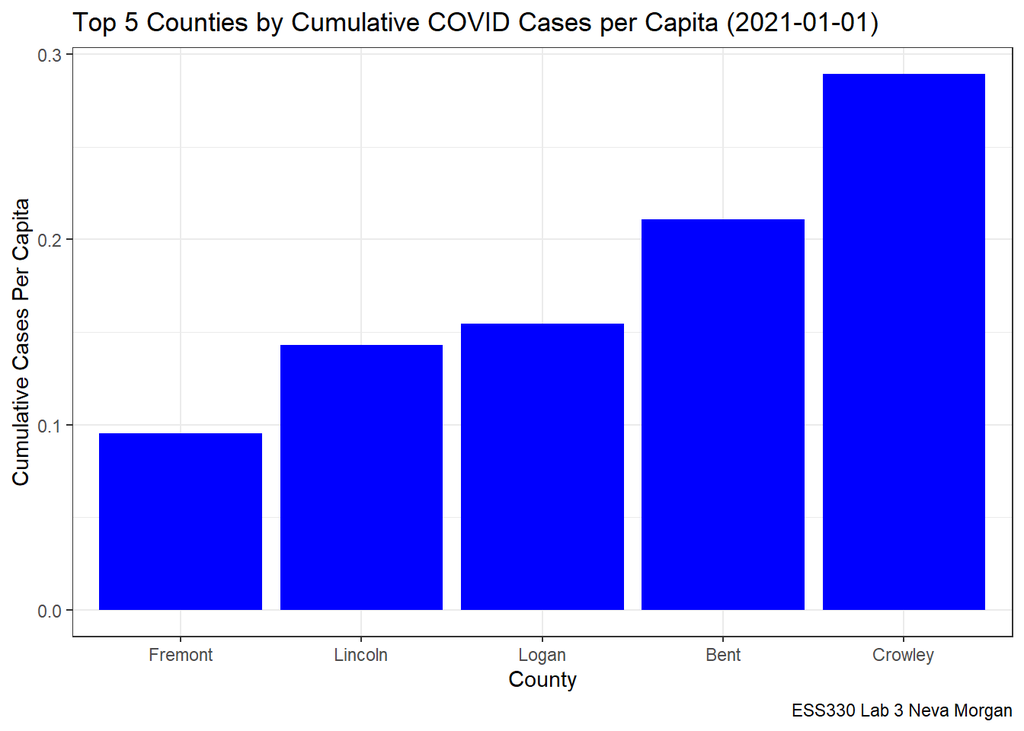

```r
CO_counties <- colorado_combined |>
  filter(date == "2021-01-01") |>
  arrange(desc(percapita_cumulative_cases)) |>
  slice_head(n = 5)

ggplot(CO_counties, aes(x = reorder(county, percapita_cumulative_cases), y = percapita_cumulative_cases)) +
  geom_col(fill = "blue") +
  labs(
    title = "Top 5 Counties by Cumulative COVID Cases per Capita (2021-01-01)",
    caption = "ESS330 Lab 3 Neva Morgan",
    x = "County",
    y = "Cumulative Cases Per Capita"
  ) +
  theme_bw()
```

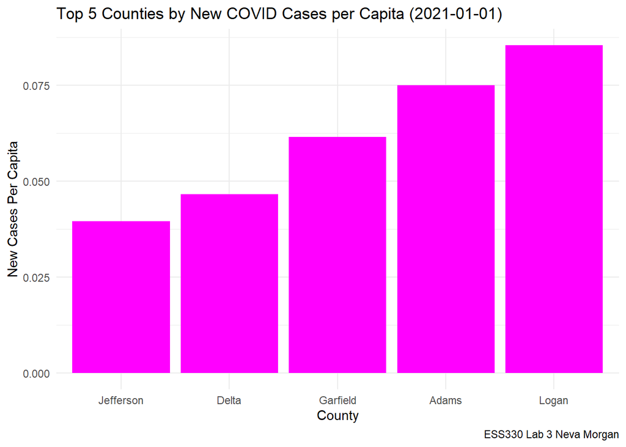

```r
CO_new_counties <- colorado_combined |>
  filter(date == "2021-01-01") |>
  arrange(desc(percapita_new_cases)) |>
  slice_head(n = 5)

ggplot(CO_new_counties, aes(x = reorder(county, percapita_new_cases), y = percapita_new_cases)) +
  geom_col(fill = "magenta") +
  labs(
    title = "Top 5 Counties by New COVID Cases per Capita (2021-01-01)",
    caption = "ESS330 Lab 3 Neva Morgan",
    x = "County",
    y = "New Cases Per Capita"
  ) +
  theme_minimal()
```

# **Question 4: Rolling thresholds**

#### Filter the merged COVID/Population data to only include the last 14 days. Remember this should be a programmatic request and not hard-coded. Then, use the group_by/summarize paradigm to determine the total number of new cases in the last 14 days per 100,000 people. Print a table of the top 5 counties, and, report the number that meet the watch list condition: “More than 100 new cases per 100,000 residents over the past 14 days…”

(Hint: Dates are numeric in R and thus operations like max min, -, +, >, and< work.)

Last 14 days:

```r
colorado_combined <- colorado_combined |>
  mutate(date = as.Date(date))

current_date <- max(colorado_combined$date, na.rm = TRUE)

current_data <- colorado_combined |>
  filter(date >= (current_date - 13) & date <= current_date)
```

Total Number of Cases within Last 14 Days Per 100,000 People plus Top 5 Counties

```r
cases_14_summary <- current_data |>
  group_by(county) |>
  summarize(
    total_new_cases = sum(new_cases, na.rm = TRUE),
    population = first(POPESTIMATE2021),
    cases_100k = (total_new_cases / population) * 100000) |>
  arrange(desc(cases_100k))

top_counties <- cases_14_summary |>
  slice_head(n = 5) |>
  print()
```

```
# A tibble: 5 × 4
  county    total_new_cases population cases_100k
  <chr>               <int>      <int>      <dbl>
1 Adams             1853160     523544    353965.
2 Garfield           204491      62107    329256.
3 Douglas            965438     369783    261082.
4 Jefferson         1508456     580703    259764.
5 Delta               61261      31392    195148.
```

Watch List?

```r
watchlist_data <- cases_14_summary |>
  filter(cases_100k > 100) |>
  nrow()

cat("Number of Counties That Meet the Watchlist Conditions", watchlist_data)
```

```
Number of Counties That Meet the Watchlist Conditions 40
```

# **Question 5: Death toll**

#### Given we are assuming it is February 1st, 2022. Your leadership has asked you to determine what percentage of deaths in each county were attributed to COVID last year (2021). You eagerly tell them that with the current Census data, you can do this!

```r
covid_2021_year <- colorado_combined |>
  filter(date >= "2021-01-01" & date <= "2021-12-31")

total_deaths <- covid_2021_year |>
  group_by(county) |>
  summarize(total_deaths = sum(deaths, na.rm = TRUE))

total_covid_deaths <- covid_2021_year |>
  group_by(county) |>
  summarize(total_covid_deaths = sum(new_deaths, na.rm = TRUE))

deaths_merged <- total_covid_deaths|>
  left_join(total_deaths, by = "county")


deaths_merged <- deaths_merged |>
  mutate(
    covid_death_percentage = (total_covid_deaths / total_deaths) * 100
  ) |>
  arrange(desc(covid_death_percentage)) |>
  glimpse()
```

```
Rows: 64
Columns: 4
$ county                 <chr> "San Juan", "Adams", "Garfield", "Delta", "Doug…
$ total_covid_deaths     <int> 61, 271299, 16236, 20721, 79078, 229437, 15409,…
$ total_deaths           <int> 61, 279442, 18256, 25795, 99698, 297375, 26068,…
$ covid_death_percentage <dbl> 100.0000000, 97.0859785, 88.9351446, 80.3295212…
```

#### From previous questions you should have a data.frame with daily COVID deaths in Colorado and the Census based, 2021 total deaths. For this question, you will find the ratio of total COVID deaths per county (2021) of all recorded deaths. In a plot of your choosing, visualize all counties where COVID deaths account for 20% or more of the annual death toll.

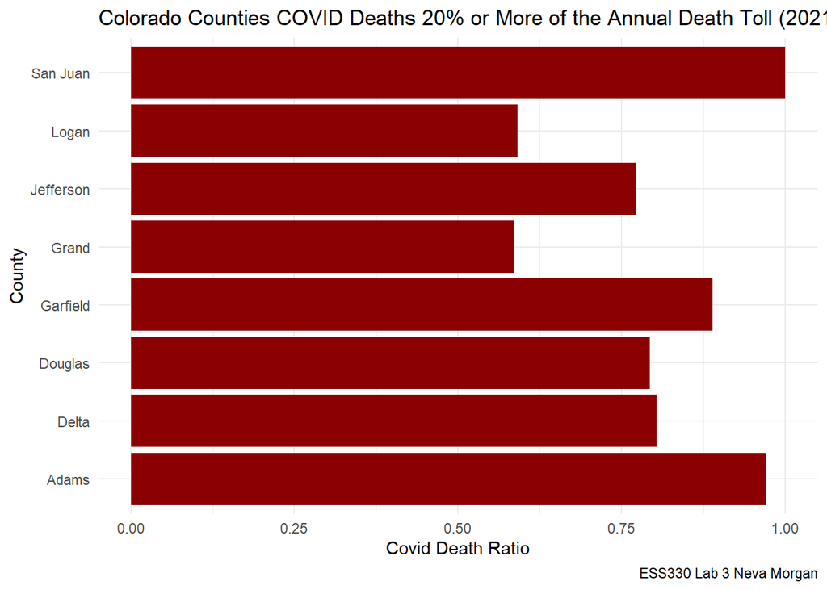

```r
deaths_merged <- deaths_merged |>
  mutate(
    covid_death_ratio = total_covid_deaths / total_deaths
  )

counties_20 <- deaths_merged |>
  filter(covid_death_ratio >= 0.20) |>
  arrange(desc(covid_death_ratio))

ggplot(data = counties_20, mapping = aes(x = county, y = covid_death_ratio)) +
  geom_col(fill = "darkred") +
  coord_flip() +
  labs(
    title = "Colorado Counties COVID Deaths 20% or More of the Annual Death Toll (2021)",
    caption = "ESS330 Lab 3 Neva Morgan",
    x = "County",
    y = "Covid Death Ratio"
  ) +
  theme_minimal()
```

# **Question 6: Multi-state**

#### In this question, we are going to look at the story of 4 states and the impact scale can have on data interpretation. The states include: New York, Colorado, Alabama, and Ohio. Your task is to make a faceted bar plot showing the number of daily, new cases at the state level.

## **Steps:**

In this question, we are going to look at the story of 4 states and the impact scale can have on data interpretation. The states include: New York, Colorado, Alabama, and Ohio. Your task is to make a faceted bar plot showing the number of daily, new cases at the state level.

1. First, we need to `group/summarize` our county level data to the state level, `filter` it to the four states of interest, and calculate the number of daily new cases (`diff/lag`) and the 7-day rolling mean.

```r
state_covid <- covid_data |>
  filter(state %in% c("New York", "Colorado", "Alabama", "Ohio")) |>
  group_by(county) |>
  arrange(date) |>
  mutate(new_cases = cases - lag(cases),
         new_deaths = deaths - lag(deaths)) |>
  ungroup()

state_covid <- state_covid |>
  group_by(state, county, date, new_cases) |>
  summarize(daily_new_cases = sum(new_cases, na.rm = TRUE), .groups = "drop") |>
  filter(state %in% c("New York", "Colorado", "Alabama", "Ohio")) |>
  arrange(state, date)

state_covid <- state_covid |>
  mutate(
    daily_new_cases = new_cases - lag(new_cases, default = 0),
    rolling_mean_7day = rollmean(daily_new_cases, 7, fill = NA, align = "right")
  ) |>
  glimpse()
```

```
Rows: 216,632
Columns: 6
$ state             <chr> "Alabama", "Alabama", "Alabama", "Alabama", "Alabama…
$ county            <chr> "Elmore", "Jefferson", "Limestone", "Montgomery", "T…
$ date              <chr> "2020-03-13", "2020-03-13", "2020-03-13", "2020-03-1…
$ new_cases         <int> NA, -3, NA, NA, NA, NA, 0, -1, 0, 0, 1, 0, 0, 4, NA,…
$ daily_new_cases   <int> NA, NA, NA, NA, NA, NA, NA, -1, 1, 0, 1, -1, 0, 4, N…
$ rolling_mean_7day <dbl> NA, NA, NA, NA, NA, NA, NA, NA, NA, NA, NA, NA, NA, …
```

2. Using the modified data, make a facet plot of the daily new cases and the 7-day rolling mean. Your plot should use compelling geoms, labels, colors, and themes.

[figure not shown]

```r
ggplot(state_covid, aes(x = date, y = daily_new_cases, fill = state)) +
  geom_col(show.legend = FALSE) +
  geom_line(aes(y = rolling_mean_7day, color = state), linewidth = 1.2) +
  facet_wrap(~ state, scales = "free_y") +
  labs(
    title = "Daily New COVID Cases with 7-Day Rolling Mean",
    caption = "ESS330 Lab 3 Neva Morgan",
    x = "Date",
    y = "New Cases"
  ) +
  theme_minimal() +
  theme(axis.text.x = element_text(angle = 45, hjust = 1))
```

3. The story of raw case counts can be misleading. To understand why, lets explore the cases per capita of each state. To do this, join the state COVID data to the population estimates and calculate the newcases/totalpopulation. Additionally, calculate the 7-day rolling mean of the new cases per capita counts.

```r
pop_data <- pop_data |>
  rename(state = STNAME) |>
  rename(county = CTYNAME)

state_pop_data <- pop_data |>
  filter(state %in% c("New York", "Colorado", "Alabama", "Ohio")) |>
  group_by(state, county) |>
  summarize(total_population = sum(POPESTIMATE2021, na.rm = TRUE), .groups = "drop")
```

```r
state_covid_aggregated <- state_covid |>
  group_by(state, date) |>
  summarize(daily_new_cases = sum(daily_new_cases, na.rm = TRUE), .groups = "drop")

state_covid_percapita <- state_covid_aggregated |>
  left_join(state_pop_data, by = "state") |>
  mutate(
    new_cases_per_capita = daily_new_cases / total_population,
    rolling_mean_per_capita = rollmean(new_cases_per_capita, 7, fill = NA, align = "right")
  )
```

4. Using the per capita data, plot the 7-day rolling averages overlying each other (one plot) with compelling labels, colors, and theme.

[figure not shown]

```r
ggplot(state_covid_percapita, aes(x = date, y = rolling_mean_per_capita, color = state)) +
  geom_line(size = 5) +
  labs(
    title = "7-Day Rolling Average of COVID Cases Per Capita",
    caption = "ESS330 Lab 3 Neva Morgan",
    x = "Date",
    y = "New Cases Per Capita",
    color = "State"
  ) +
  theme_minimal() +
  theme(axis.text.x = element_text(angle = 45, hjust = 1))
```

# **Question 7: Space & Time**

#### For our final task, we will explore our first spatial example! In it we will calculate the Weighted Mean Center of the COVID-19 outbreak in the USA to better understand the movement of the virus through time.

#### To do this, we need to join the COVID data with location information. I have staged the latitude and longitude of county centers here.

Please read in the data (readr::read_csv()); and join it to your raw COVID-19 data using the fips attributes using the following URL:

Code

```r
library(sf)
counties <- read_csv('https://raw.githubusercontent.com/mikejohnson51/csu-ess-330/refs/heads/main/resources/county-centroids.csv')
covid_data <- covid_data |>
  mutate(fips = as.character(fips))

counties <- counties |>
  mutate(fips = as.character(fips))

covid_data_with_coords <- covid_data |>
  left_join(counties, by = "fips")
```

For each date, calculate the Weighted Mean and using the daily cumulative cases and the weight . In addition, calculate the total cases for each day, as well as the month. Hint: the month can be extracted from the date column using format(date, “%m”)

```r
covid_data_with_coords$date <- as.Date(covid_data_with_coords$date)

covid_data_with_coords <- covid_data_with_coords |>
  mutate(month = format(date, "%m"))

total_cases_per_day <- covid_data_with_coords |>
  group_by(date) |>
  summarize(total_cases = sum(cases, na.rm = TRUE), .groups = "drop")

covid_data_with_coords <- covid_data_with_coords |>
  left_join(total_cases_per_day, by = "date")
```

```r
wmc_data <- covid_data_with_coords |>
  group_by(date) |>
  summarize(
    weighted_lat = sum(LAT * total_cases) / sum(total_cases, na.rm = TRUE),
    weighted_lon = sum(LON * total_cases) / sum(total_cases, na.rm = TRUE),
    total_cases = total_cases[1],
    month = month[1],
    .groups = "drop"
  )
```

Plot the weighted mean center (aes(x = LNG, y = LAT)), colored by month, and sized by total cases for each day. These points should be plotted over a map of the USA states which can be added to a ggplot object with:

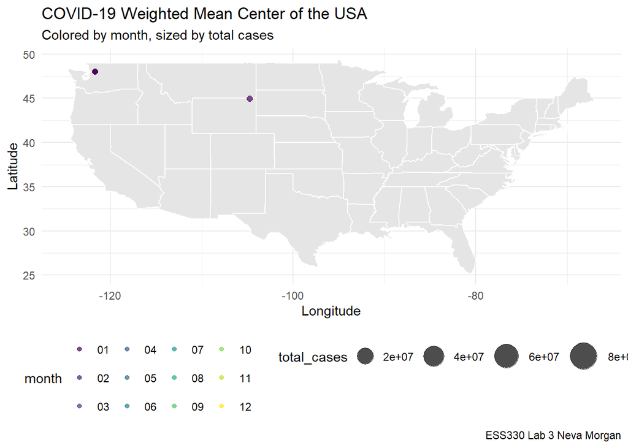

```r
ggplot() +
  borders("state", fill = "gray90", colour = "white") +
  geom_point(data = wmc_data, aes(x = weighted_lon, y = weighted_lat, color = month, size = total_cases),
             alpha = 0.7) +
  scale_color_viridis_d() +
  scale_size_continuous(range = c(2, 10)) +
  labs(
    title = "COVID-19 Weighted Mean Center of the USA",
    subtitle = "Colored by month, sized by total cases",
    caption = "ESS330 Lab 3 Neva Morgan",
    x = "Longitude",
    y = "Latitude"
  ) +
  theme_minimal() +
  theme(legend.position = "bottom")
```

(feel free to modify fill and colour (must be colour (see documentation)))